# Análise de Demonstrativos e Indicadores

Ross Cap 03

Marcelo S. Perlin

EA-UFRGS

20/08/2026

# 1 Fontes e Usos

## 1.1 Definições

- Fontes
  - Entradas de caixa - ocorrem quando “vendemos” algo
  - Redução em contas do ativo (BP): Contas a receber, Estoques, Imobilizado líquido
  - Aumento de obrigações ou na conta de capital próprio
    - Contas a pagar, outros passivos, Patrimonio Líquido
- Usos
  - Saídas de caixa - ocorrem quando “compramos” algo
    - Aumento em contas do Ativo: Estoques, Contas a Receber, Equipamentos
  - Redução em obrigações ou na conta de capital
    - Empréstimos de curto prazo, dívidas de longo prazo, Patrimônio Líquido

# 2 Demonstrações financeiras uniformes

## 2.1 Introdução

> A uniformização de demonstrativos financeiros permite a comparação entre resultados obtidos em períodos diferentes, ou entre empresas diferentes.
- Balanços patrimoniais uniformes
  - Compute como percentuais do Ativo Total
- Demonstrações de resultado uniformes
  - Compute todas as linhas como percentuais das vendas
  - Demonstrações uniformes tornam mais fácil a comparação de informações financeiras, especialmente à medida que a empresa cresce
  - Também são úteis para comparar empresas com tamanhos diferentes, especialmente dentro do mesmo ramo.

## 2.2 Análise Horizontal e Vertical

- Análise Horizontal
  - Demonstra a evolução das contas ao longo do tempo.
    - Exemplo: O aumento percentual nas vendas de um ano para outro.
- Análise Vertical
  - Demonstra a percentagem das contas em relação à uma conta base.
    - Exemplo: Para determinado ano, o percentual da conta caixa em relação ao ativo total.

## 2.3 Exemplo de Balanço Patrimonial

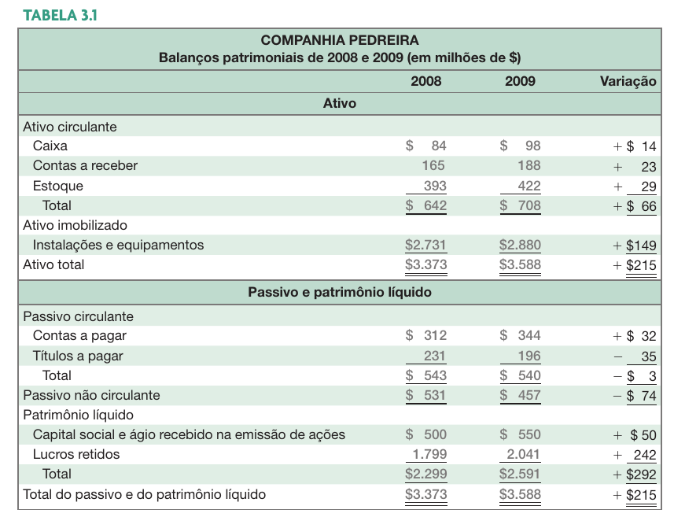

Retirado de Ross et al. (2022) página 54

## 2.4 Exemplo de Demonstração de Resultados

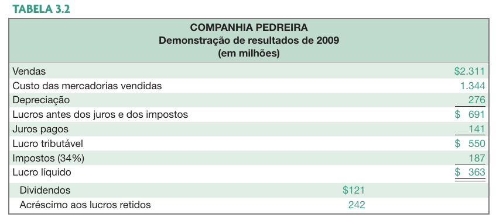

Retirado de Ross et al. (2022) página 55

## 2.5 Exemplo Padronização Vertical

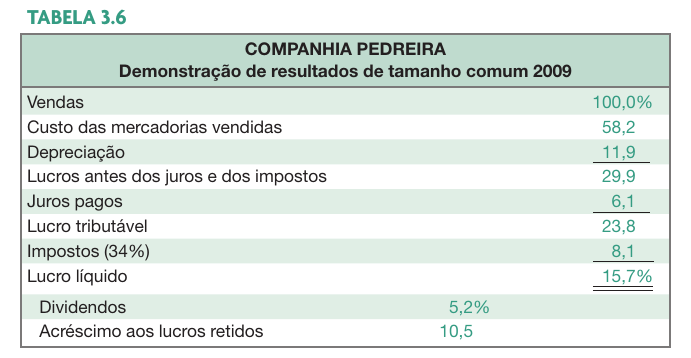

Retirado de Ross et al. (2022) página 59

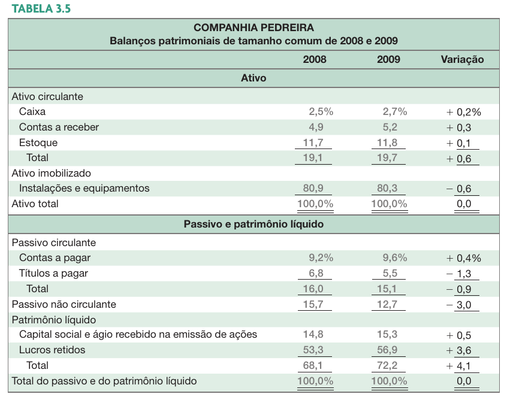

Retirado de Ross et al. (2022) página 58

# 3 Análise de DFs através de índices

## 3.1 Motivação

- Excesso de Informações nas DF e necessidade de simplificação
- A padronização permite a análise da situação financeira e econômica (Estrutura, Liquidez, Rentabilidade)
- **Tipos de Índices:**
  - Solvência ou liquidez
  - Solvência a longo prazo (índices de alavancagem)
  - Gestão de ativos (indicadores de giro)
  - Rentabilidade
  - Valor de mercado

## 3.2 Valores do BP (para cálculos de índices)

Retirados de BP anterior, Seção 2.3

```r
# Valores para 2009
AC <- 708
contasareceber <- 188
PC <- 540
estoques <- 422
caixa <- 98
CR <- 188
AnC <- 2880
AT <- 3588
PL <- 2591
PnC <- 457
PT <- AT
CCL <- AC - PC
```

## 3.3 Valores do DRE (para cálculos de índices)

Retirados de DRE anterior, Seção 2.4

```r
# Valores para 2009
vendas <- 2311
CMV <- 1344
despesas <- 0
juros <- 141
LAJIR <- 691
depreciacao <- 276
LL <- 363
```

## 3.4 Índices de liquidez (1/2)

**Liquidez Corrente**

$$LC=\frac{AC}{PC} \Longrightarrow 708/540 = 1.3111111$$

**Liquidez Seca**

$$LS=\frac{AC-Estoques}{PC} \Longrightarrow 0.5296296$$

**Índice de caixa**

$$IC=\frac{Caixa}{PC} \Longrightarrow 0.1814815$$

Nota: todos cálculos foram efetivados com informações do BP e DRE do início dos slides

## 3.5 Índices de liquidez (2/2)

**Prazo de cobertura de gastos de curto prazo**

$$PCGCP=\frac{AC}{CustosOperacionaisDiarios} \Longrightarrow \frac{AC}{(CMV+despesas)/365} \Longrightarrow 192.2767857$$

## 3.6 Calculando índices de solvência a longo prazo

**Endividamento total**

$$ET=\frac{AT - PL}{AT} \Longrightarrow 0.2778707$$

**Dívida/PL**

$$\frac{PC + PnC}{PL} \Longrightarrow 0.3847935$$

**Multiplicador do PL**

$$MPL=\frac{AT}{PL} \Longrightarrow 1.3847935$$

**Endividamento a longo prazo**

$$ELP=\frac{PnC}{PL} \Longrightarrow 0.1763798$$

## 3.7 Calculando índices de cobertura

**Índice de cobertura de juros**

$$ICJ=\frac{LAJIR}{Juros} \Longrightarrow 4.9007092$$

**Índice de cobertura de caixa**

$$ICC=\frac{LAJIR + Depreciação}{Juros} \Longrightarrow 6.858156$$

## 3.8 Calculando indicadores de estocagem

**Giro dos estoques**

$$GE=\frac{CustoMercadoriaVendida}{estoques} \Longrightarrow 3.1848341$$

**Prazo Médio de Estocagem**

$$PME=\frac{365}{GE} \Longrightarrow 114.6056548$$

## 3.9 Indicadores de contas a receber

**Giro de contas a receber**

$$GCR=\frac{vendas}{contasareceber} \Longrightarrow 12.2925532$$

**Prazo Médio de Recebimento**

$$PMR=\frac{365}{GCR} \Longrightarrow 29.6927737$$

## 3.10 Indicadores de giro do Ativo

**Giro do Ativo**

$$GA=\frac{Vendas}{AT} \Longrightarrow 0.6440914$$

**Giro do CCL**

$$GCCL=\frac{Vendas}{CCL} \Longrightarrow 13.7559524$$

**Giro do Imobilizado**

$$GI =\frac{Vendas}{ImobilizadoLiquido} \Longrightarrow 0.8024306$$

## 3.11 Indicadores de rentabilidade

**Margem de lucro**

$$ML =\frac{LucroLíquido}{Vendas} \Longrightarrow 0.1570749$$

**Retorno do Ativo (ROA)**

$$ROA =\frac{LucroLíquido}{AtivoTotal} \Longrightarrow 0.1011706$$

**Retorno do Patrimônio Líquido (ROE)**

$$ROE =\frac{LucroLíquido}{PatrimonioLiquido} \Longrightarrow 0.1401003$$

## 3.12 Indicadores de valor de mercado

Preço de mercado: R$ 15,56 por ação

Ações em circulação: 200

**Índice Preço/Lucro**

$$PL =\frac{PreçoAção}{LucroPorAção} \Longrightarrow 8.5730028$$

**Índice valor de mercado / valor contábil (V/VP)**

$$VVP =\frac{PreçoAção}{ValorPatrimonialPorAção} \Longrightarrow 1.2010807$$

## 3.13 Onde achar informações de índices

[figure not shown]

Status Invest

https://statusinvest.com.br/

# 4 O Caso Petrobrás (Valor Econômico – ago 2014)

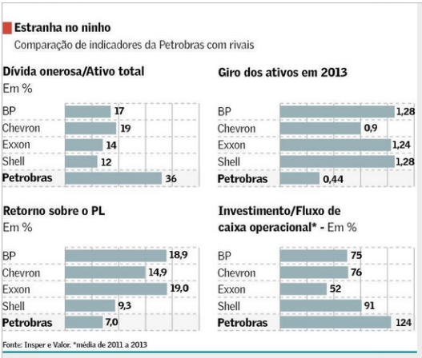

Fonte: http://www.valor.com.br/financas/3660042/petrobras-destoa-de-rivais-estrangeiras

## Referências

Ross, Stephen, Randolph Westerfield, Bradford Jordan, et al. 2022. *Fundamentos de Administração Financeira*. Bookman Editora.